# Trading strategy building and statistical testing

*Written by: Zsolt Diveki, PhD*

# Content

# 1) Introduction

The intention of this document is to describe a few simple trading strategies and their application in python in order to give ideas to others how they could build and test strategies. It is not our intention to present a solid framework of trading machine that includes every aspect of algorithmic trading. Also we do not force to present profitable setups although we careful design probably they can be turned into profitable ones. Rather we would like to put the emphasis on the importance of statistical testing of the ideas.

We will present three trading strategies, moving average cross over trend, momentum trend and relative value pair trading. In each example we present trading rules, position sizing and optimization of some parameters with different types of statistical tests. Although each of these steps could be analysed and optimized separately, we only select one parameter to optimize in each strategy according to a predifined goodness of fit measure.

# 2) Getting data

Before starting building trading strategies we have to get data to work with. We will use inbuilt pandas methods to obtain data from finance.google.com.

## 2.1) Download prices with pandas

We import first some python libraries that will help our work:

```python
import matplotlib.pyplot as plt
import pandas as pd
import pandas.io.data as web
import datetime as dt
from datetime import timedelta
```

We define a helping function first. Based on an input date this function makes sure that the output is a week day. It requires a *datetime* type date as an input.

```python
def find_last_weekday(x):
    '''Finds the last weekday and returns it!
    x - datetime type date '''
    from datetime import datetime, timedelta   # import datetime libraries
    while datetime.weekday(x) in [5,6]:        # check if the date is a weekend
        x = x - timedelta(1)
    return(x)
```

Download Apple Inc. stock prices using *pandas DataReader* function:

```python
# setting a variable to the name of stocks we want to download: Apple
stocks    =     'AAPL'
# set the start date of the time series
start     =     dt.datetime(1990, 1, 4)
# set the end date as the last working day as of yesterday
end = find_last_weekday(dt.datetime.today()-timedelta(1))
f = web.DataReader(stocks, 'google', start, end)
```

Plot the OHLC prices in one plot and the volume below it:

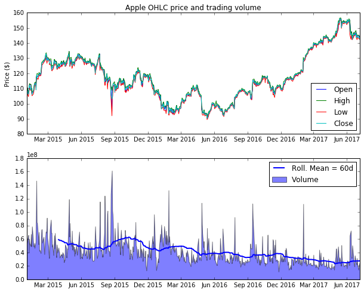

```python
%matplotlib inline
# make the figures appear in the notebook
# select OHLC data starting from 2015
top_plot = f[['Open', 'High', 'Low', 'Close']]['2015-01-01':]
# storing volumes in a different variable
bottom_plot = f[['Volume']]['2015-01-01':]
# creating a figure with predifined size
plt.figure(figsize=(10,8))
# creating the upper plot for OHLC data
plt.subplot(211)
# plotting OHLC data one by one
for name in top_plot.columns:
    plt.plot(top_plot[name], label = name)
plt.legend(loc='best')                                                # making legend visible
plt.ylabel('Price ($)')                                               # adding y-axis label
plt.title('Apple OHLC price and trading volume')                      # adding title
plt.subplot(212)                                                      # preparing the bottom plot
plt.fill_between(bottom_plot.index, bottom_plot.Volume, \
                 where=bottom_plot.Volume<=bottom_plot.Volume, alpha=0.5, label='Volume')
# plotting the volume in a shaded area
plt.plot(pd.rolling_mean(bottom_plot, window=60), label='Roll. Mean = 60d', lw=2, color='blue')
# plotting rolling mean of the volume with a window size of 60 days
plt.legend(loc='best')                                                # adding legend
plt.show()
```

One of the performance tests will be cross asset strategy testing, therefore we define a function that is able to return a dataframe with several columns containing the historical close prices of different stocks.

```python
def get_prices(names, start, end):
    '''Function for getting historical prices of several stocks
    Input:
    names - list of stock name strings
    start - datetime/date/string type of date of first price tick
    end   - datetime/date/string type of date of last price tick
    Output:
    pandas dataframe of historical stock prices
    '''
    # set the end date as the last working day as of yesterday
    end = find_last_weekday(end)
    # rename the close column to its stock name and create a
    # dataframe with columns of different stocks
    f = pd.DataFrame({name: web.DataReader(name, 'google', \
                                           start, end)['Close'] for name in names})
    # fills in missing values with previous days value
    f.fillna(method = 'ffill', inplace = True)
    return(f)
```

# 3) Building and testing trend strategies

In this chapter we create, optimize and test two trend strategies. The emphasize is rather on the optimization and statistical tests than on creating profitable strategies. The two strategies that will be presented here are:

1. Moving average cross over signal generation.
2. Momentum based trend strategy.

For simplicity we neglect slippage and trading costs. We will use kfold and bootstrap for performance optimization and testing.

## 3.1) Moving average cross over trend

This technique is based on the calculation of a fast and a slow simple moving average (MA) price series that will be used to predict the direction of the price movement. Lets look at how does two different MA look like for the Apple close prices obtained from Google. One must be careful with prices series obtained from Google because they might not well back adjusted for dividends and share splits therefore any strategy would create false signals. Since our objective is to show examples of how to create, optimize and test trading strategies and not to create trading ready algorithms, we do not go through data back adjustment.

Let us take the close values of Apple and calculate the 200 days and 50 days moving average of it and visualize it.

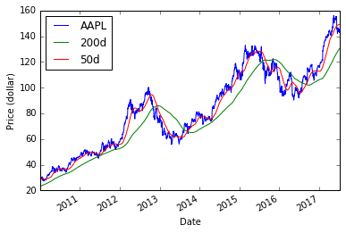

```python
names=['AAPL']
start     =     dt.datetime(1990, 1, 4)
end = find_last_weekday(dt.datetime.today()-timedelta(1))

apple = get_prices(names, start, end)
fast_ma = 50                        # lookback of the fast MA
slow_ma = 200                       # lookback of the slow MA
# calculation of the slow MA
apple[str(slow_ma)+'d'] = pd.rolling_mean(apple['AAPL'], window = slow_ma)
# calculation of the fast MA
apple[str(fast_ma)+'d'] = pd.rolling_mean(apple['AAPL'], window = fast_ma)

plt.figure(figsize = (10,7))
apple['2010-01-01':].plot()
plt.ylabel('Price (dollar)')
```

```python
apple['Ret'] = (apple['AAPL'] - apple['AAPL'].shift(1)) / apple['AAPL'].shift(1)
```

## 3.2) Trading rules

It is time to set up rules for trading based on the MA indicators:

- BUY: when fast MA > slow MA + delta
- SELL: when fast MA < slow MA - delta
- NEUTRAL: when (slow MA - delta) < fast MA < (slow MA + delta).

Our first step will be to calculate the difference between the fast and slow MAs. For simplicity we assume that we buy (or sell) only one share and keep them until the signal says so.

## 3.3) Optimization of delta

To investigate the right range of delta we plot the histogram of the difference of the fast and slow MAs.

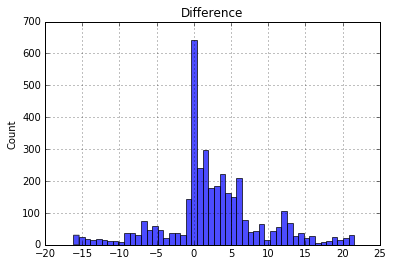

```python
apple['Difference'] = apple['50d']-apple['200d']
apple.hist(column='Difference', bins=50, alpha=0.7)
plt.ylabel('Count')
```

```python
delta = np.arange(-15, 20, 1)                # sampling range for delta
apple.dropna(inplace=True)                   # remove NaNs from the dataframe
# initialize time ranges that we will scan through for the training set
train_dates = np.arange(2006,2016)
# initialize time ranges that we will scan through for the test set
test_dates = train_dates + 2
```

We can see that the difference ranges from -15 to 20. This will be our sampling range for *delta*. Also we have initialized time ranges that we scan for the training and testing set.

In the next step we define a few useful functions that will help us to keep our code concise:

- *calculate_positions* - based on the difference of fastMA and slowMA and the delta we determine the signals to go short or long one share.
- *calculate_pnl* - based on the previously obtained signals we calculate what pnl would we take home each day.
- *information_ratio* - definition of the goodness of fit measure, the information ratio.

```python
def calculate_positions(df, delta):
    '''
    Calculate unit positions.
    Inputs:
        df     - data frame of the difference of fastMA and slowMA
        delta  - list of deviations from the differences.
    Output:
        a      - data frame with unit positions for different deltas
    '''
    a=pd.DataFrame()
    for dlt in delta:
        a[str(dlt)] = np.where(df['Difference'] > dlt, 1, 0)
        a[str(dlt)] = np.where(df['Difference'] < -dlt, -1, a[str(dlt)])
    a.set_index(df.index, inplace=True)
    return(a)

def calculate_pnl(df, ret):
    '''
    Calculate daily profit and loss based on the given positions.
    Inputs:
        df     - data frame of the unit positions
        ret    - series of daily returns calculated from daily prices
    Output:
        tmp    - data frame with daily pnls
    '''
    tmp = pd.DataFrame()
    for col in df.columns:
        tmp[col] = df[col] * ret
    tmp.dropna(inplace = True)
    return(tmp)

def information_ratio(pnl):
    '''
    Calculate information ratio.
    Inputs:
        pnl    - series, np.arrays of daily pnls
    Output:
        tmp    - annualized information ratio
    '''
    tmp = np.mean(pnl) * np.sqrt(252) / np.std(pnl)
    return(tmp)
```

When trading we can pocket the return of the nth day by having the position of the (n-1)th day. Therefore, we have to shift forward the signalled positions by one day to combine them with the right returns. This is done in the *calculate_pnl* function.

In the following lines we calculate the positions and pnls in advance for the whole history (with all possible deltas), so that we do not have to do it each time when rolling. This is acceptable when dealing with small data, but with high frequency multi year data we could not do it.

```python
pos = calculate_positions(apple, delta)
pos = pos.shift(1).dropna()
pnl = calculate_pnl(pos, apple['Ret'])
```

Next we implement the rolling cross over optimization. We train over a 5 year window. We create variables to save the information ratios for the training and test sets and a variable to store the optimal deltas from the process. The optimal delta is calculated from the training set and immediately applied on the test set.

We will apply two different optimization processes: a) take the *delta* that provides the largest information ratio on the training set b) take the positive information ratios from the training set and average the corresponding *delta*s to obtain the optimized one.

a)

```python
ir_train = pd.DataFrame()             # variable to store information ratios from training set
ir_test = pd.Series()                 # variable to store information ratios from test set
dlts = pd.Series()                    # variable to store optimized deltas
lookback = 5                          # number of years to look back in time
for i in np.arange(len(train_dates)):
    # subset the training set
    train = pnl[str(train_dates[i]-lookback):str(train_dates[i])]
    # calculate the information ratio for each delta in the training set
    ir_train[str(train_dates[i]-lookback) + '-' + str(train_dates[i])] = \
        train.apply(information_ratio, axis = 0)
    # choose the delta that belongs the largest information ratio
    dlts[str(train_dates[i]+1)+'-'+str(test_dates[i])] = \
        float(ir_train.where(ir_train.ix[:,i]==ir_train.ix[:,i].max()).dropna().index[0])
    # subset the test set
    test  = apple[str(train_dates[i]+1):str(test_dates[i])]
    # calculate the unit positions with test set and optimized delta
    pos_test = calculate_positions(test, [dlts.ix[i].tolist()])
    pos_test = pos_test.shift(1).dropna()
    # calculate the corresponding pnl
    pnl_test = calculate_pnl(pos_test, apple['Ret'])
    # determine the information ratio on the test set
    ir_test[str(train_dates[i]+1) + '-' + str(test_dates[i])] = \
        information_ratio(pnl_test).values[0]
```

Repeat the same procedure as above for the b) approach.

```python
ir_train_mean = pd.DataFrame()
ir_test_mean = pd.Series()
dlts_mean = pd.Series()
for i in np.arange(len(train_dates)):
    train = pnl[str(train_dates[i]-lookback):str(train_dates[i])]
    ir_train_mean[str(train_dates[i]-lookback) + '-' + str(train_dates[i])] = \
            train.apply(information_ratio, axis = 0)
    tmp = ir_train_mean.where(ir_train_mean.ix[:,i]>0).dropna().index
    dlts_mean[str(train_dates[i]+1)+'-'+str(test_dates[i])] = \
            np.array([float(xx) for xx in tmp.tolist()]).mean()
    test  = apple[str(train_dates[i]+1):str(test_dates[i])]
    pos_test = calculate_positions(test, [dlts_mean.ix[i].tolist()])
    pos_test = pos_test.shift(1).dropna()
    pnl_test = calculate_pnl(pos_test, apple['Ret'])
    ir_test_mean[str(train_dates[i]+1) + '-' + str(test_dates[i])] = \
            information_ratio(pnl_test).values[0]
```

Let us print out the information ratios for a) and b) for all the test ranges. We also print out their mean and standard deviation.

```python
for i in range(ir_test_mean.shape[0]):
    print('Test range: %s IR(a): %.3f, IR(b): %.3f' % \
          (ir_test.index[i], ir_test.ix[i], ir_test_mean.ix[i]))
print('Mean(IR(a)): %.3f, Mean(IR(b)): %.3f' % (ir_test.mean(), ir_test_mean.mean()))
print('Std(IR(a)): %.3f, Std(IR(a)): %.3f' % (ir_test.std(), ir_test_mean.std()))
```

```
Test range: 2007-2008 IR(a): -0.049, IR(b): -0.045
Test range: 2008-2009 IR(a): -0.781, IR(b): -1.105
Test range: 2009-2010 IR(a): 1.222, IR(b): 1.003
Test range: 2010-2011 IR(a): 1.341, IR(b): 1.056
Test range: 2011-2012 IR(a): 1.009, IR(b): 1.009
Test range: 2012-2013 IR(a): 1.067, IR(b): 0.981
Test range: 2013-2014 IR(a): 1.335, IR(b): 1.270
Test range: 2014-2015 IR(a): 0.790, IR(b): 0.831
Test range: 2015-2016 IR(a): 0.177, IR(b): 0.177
Test range: 2016-2017 IR(a): 0.807, IR(b): 0.807
Mean(IR(a)): 0.692, Mean(IR(b)): 0.598
Std(IR(a)): 0.696, Std(IR(a)): 0.725
```

Our job is now to make a decision which approach, a) or b), is more profitable to us. From the previously printed statistics we can see that the results are very close to each other. With regard to the fact that we do not have many samples (less than 30) we will have difficulty to make a confident decision. Nevertheless we will present a approach to do that.

We will assume that the samples of both a) and b) are coming from a normal distribution. This is a very weak statement since we do not have many samples, but we rely on the central limit theory, which states that given a sufficiently large sample size the distribution of the samples will follow a normal distribution.

We can use the t-test to decide if the two samples are coming from the same normal population, based on their mean value. If they are coming from the same population, in ideal case they should have the same mean and same variance. In python the *scipy.stats* package has a function to calculate t-statistics and p-value. Our null hypothesis is that the two samples are coming from the same population.

```python
import scipy.stats as stats
t_stat, p_val = stats.ttest_ind(ir_test, ir_test_mean, equal_var=True)
print('t-statistic: %.5f, p-value = %.5f' % (t_stat, p_val))
```

```
t-statistic: 0.29376, p-value = 0.77231
```

From the p-value we know that there is 77% chance to observe these mean values in two samples assuming they are from the same population. This is a high probabilty therefore we cannot confidentely say (with 95% or more) that one of the approaches would perform better than the other.

# 4) Building and testing momentum strategies

In the followings we will describe briefly what is a momentum trend strategy, present an example of creating buy and sell signals from it and finally use bootstrap to optimize the lookback period to obtain the best performance from a given input.

An n-day momentum is usually defined as the difference between the price at time *t* and the price at time *t-n*. The momentum obtained this way will be used as a forecaster of tomorrow's return. We define several lookback periods and try to find the most optimal one to achieve a relatively high and stable performance. We choose the *edge* as our goodness of fit, which is not directly a performance measure like the information ratio.

Our very first task is to get some data. We will work with stock prices of Amazon. We reuse the methods introduced in Chapter 2) to retrieve the data:

```python
# define the name of the selected stock
names=['AMZN']
# start date of the price series
start     =     dt.datetime(1990, 1, 4)
# end date
end = find_last_weekday(dt.datetime.today()-timedelta(1))
# get the close price quotes of the selected stock
stock = get_prices(names, start, end)
# calculate the daily percentage return
stock['Ret'] = stock.pct_change()
```

## 4.1) Trading rules and position sizing

Let us define 5, 20, 65, 130 and 260 days lookback period. Actually one can choose any positive integer she wants and test it. Our choice represents the one week, one month, one quarter, half and one year periods. These are in general important time ranges in finance that many trading participant may consider. This common behaviour can be one of the reasons behind the existence of trend. If people believe that in 20 days the prices are going up, they will buy and naturally fuel the rise of the prices.

Next we calculate the n-day momenta and collect the results in a dataframe over the whole time range. These numbers will serve as the predictor of tomorrows daily return.

```python
# definition of lookbacks
lookback = np.array([ 5, 20, 65, 130, 260])
# copying the original data for future dataframe extension
train = stock[names]
# calculating the momentum for each lookback
for lkb in lookback:
    # momentum
    tmp = stock[names].diff(lkb)
    # renaming the column to the lookback period
    tmp.columns = [str(lkb)]
    # extending the price and returns with momenta
    train=pd.concat([train, tmp], axis=1)
```

Next we create a function that defines the trading rules. Our trading strategy for a given momentum is the following:

- If momentum > 0 -> go long
- If momentum < 0 -> go short
- If momentum = 0 -> go/stay neutral

At this stage one could also think about position sizing strategies. For simplicity, we stick to go one share long or one share short.

```python
def calculate_positions_momentum(df, delta):
    '''
    Calculate unit positions.
    Inputs:
        df     - data frame of the momenta
        delta  - list of lookback periods
    Output:
        a      - data frame with unit positions for different deltas
    '''
    # create container dataframe
    a=pd.DataFrame()
    # loop over the lookback periods
    for dlt in delta:
        # create long positions
        a[str(dlt)] = np.where(df[str(dlt)] > 0, 1, 0)
        # create short positions
        a[str(dlt)] = np.where(df[str(dlt)] < 0, -1, a[str(dlt)])
        # create neutral positions (this line is not necessary)
        a[str(dlt)] = np.where(df[str(dlt)] == 0, 0, a[str(dlt)])
    # fill the dataframe with date index
    a.set_index(df.index, inplace=True)
    return(a)
```

## 4.2) Optimization process

After determining the trading rules we divide our data into a training and a testing set. The training set will cover the data up to and including 2012. With the training set prices we calculate the momenta, the daily unit positions and finally the daily pnl according to our trading strategy.

```python
# calculate daily unit positions
pos_train = calculate_positions_momentum(train[:'2012'].dropna(), lookback)
# lag the dates to use those positions with tomorrows returns
pos_train = pos_train.shift(1).dropna()
# calculate daily pnl
pnl_train = calculate_pnl(pos_train, stock['Ret'])
```

To determine what is the ideal lookback period to use with the Amazon data we will introduce a new goodness of fit, the *edge*. The edge can be derived from the formula of the expected return with some arrangment of terms. The outcome is:

$edge = \frac{1}{2}(hr*(1 + wl))$, where:  
$hr$ - hit ratio, days with positive returns divided with the number of total days  
$wl = \frac{E[pnl > 0]}{|E[pnl < 0]|}$, the ratio between the expected positive and absolute value of negative daily returns.

This measure helps to decide whether the strategy does better or worse than a random position taker:

- edge > 0.5 -> the strategy is expected to make money on the longterm
- edge < 0.5 -> the strategy is expected to loose money on the longterm
- edge = 0.5 -> corresponds to the random position taker. Normally we would expect to loose money on the longterm at least because of the cost of trading and slippages.

We partially test the validity of these statments by determining what hr and wl corresponds to the edge value of 0.5 (random outcome). There can be several combinations for that scenario but one of them is when $hr = 0.5$ and $wl=1$. The former means that this strategy has 50% chance to get the sign of tomorrow's return right, while the latter means that the expected positive return is equal to the expected loss in absolute sense. This scenario basically corresponds to a strategy where our postion is determined by the flip of a coin.

In order to decide which lookback period is supposed to give the optimal edge we use bootstrap. In bootstrap we assume that the observed pnl sample is a good approximation of the population of pnls and by resampling it with replacement we can calculate different statistics of the edge. That will help us to observe the distribution of the possible edges and come up with a procedure that will show us which edge distribution of the lookback periods has the largest mean and smallest dispersion. This choice would mean that the reproduction of the same edge is very frequent therefore the strategy is stable in the performance.

In the followings we define the hit ratio, win loss, the edge and the bootstrap function:

```python
def hit_ratio(pnl):
    tmp = pnl[pnl > 0].shape[0] / pnl.shape[0]
    return(tmp)

def win_loss_ratio(pnl):
    tmp = - pnl[pnl > 0].mean() / pnl[pnl <= 0].mean()
    return(tmp)

def edge(pnl):
    hr = hit_ratio(pnl)
    wlr = win_loss_ratio(pnl)
    tmp = 0.5 * (hr * (1 + wlr))
    return(tmp)

def bootstrap_with_replacement(pnl, experiments = 10, samples=len(pnl)):
    '''
    Returns experiment number of resamples with replacement.
    Inputs:
    pnl         - np.array/pd.series of pnls
    experiments - number of times to resample the pnl array
    samples     - number of draws in a sample

    Output:
    tmp         - np.ndarray (matrix) of size experiments * samples
    '''
    # generate random integer matrix of experiments * samples as the index of pnl
    inds = np.random.randint(0, len(pnl), (experiments, samples))
    # for each column of pnl resampled with inds, calculate edge
    tmp = np.apply_along_axis(edge, 1, pnl[inds])
    return(tmp)
```

Now we are ready to apply bootstrap to the observed pnl samples and create a dataframe with the distribution of probable edges. To have an idea which lookback period may result in the most stable (and hopefully profitable) performance we visually inspect the histogram of edges.

[output not shown]

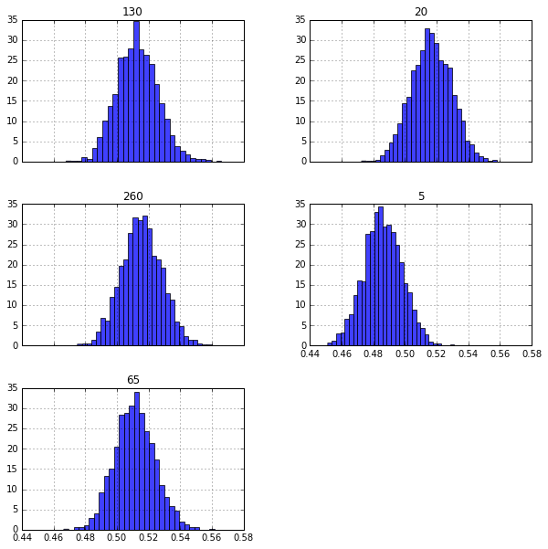

```python
# create a dataframe of edges of 3000 experiments over each lookback period
train_bts=pd.DataFrame({col: bootstrap_with_replacement(pnl_train[col], experiments=3000) for col in pnl_train.columns})
# plot a histogram of the probable edges
train_bts.hist(bins=30, figsize=(10,10), normed=1, alpha=0.75, sharex=True)
```

Even with visual inspection we can tell that the 5 days lookback strategy is most likely to loose money, since the most likely edge is smaller than 0.5. The rest of them are pretty similar, therefore we might need a different way of visualisation. Therefore we plot them on a boxplot that helps us see where is the median (horizontal red line) what is the interquartile range (top and bottom edge of the boxes), a constant multiple of interquartile range (horizontal black lines) and the outliers:

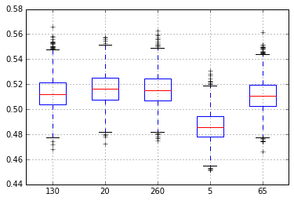

```python
lines = train_bts.boxplot(return_type='dict')
```

This representation helps us to see that the mean of 20 days lookback is the highest and the observed interquartile ranges are roughly the same. There are several ways to measure how centralized a distribution is (for example with calculating the kurtosis) but we implement a measure that is higher if the mean is high, the standard deviation and the interquartile range is small. Then we sort the value of this measure and see which lookback gives the highest number to decide which lookback might give the most stable performance:

```python
av = train_bts.mean() - train_bts.std() - (train_bts.quantile(0.75) - train_bts.quantile(0.25))
av.sort_values()
```

```
5      0.457545
65     0.481895
130    0.482261
260    0.485666
20     0.486340
dtype: float64
```

20 days seems to be the right choice. However the values of these measure are not too different, so just for sanity check we make sure that these distributions are coming from different (normal) populations. We do this comparison with the t-test:

```python
for col in train_bts.columns:
    t_stat, p_val = stats.ttest_ind(train_bts[col], train_bts['20'], equal_var=True)
    print('%s lookback: t-statistic: %.5f, p-value = %.5f' % (col, t_stat, p_val))
```

```
130 lookback: t-statistic: -11.55142, p-value = 0.00000
20 lookback: t-statistic: 0.00000, p-value = 1.00000
260 lookback: t-statistic: -2.95668, p-value = 0.00312
5 lookback: t-statistic: -95.89676, p-value = 0.00000
65 lookback: t-statistic: -16.52688, p-value = 0.00000
```

Since the p-value is really small, we can state that we are more than 95% confident that these are different distribution when the difference of their mean values are equal to the observed ones.

Now that we know that the 20 day lookback should give a stable and good performance we can test this idea out of sample. We left out from these calculation the data after 2012. In the following block we compare what information ratios would the different lookbacks give. We also include a simple buy and hold strategy (with column nem *Ret*).

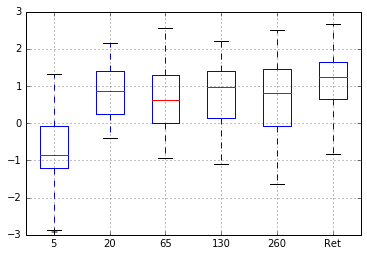

```python
# calculate the unit positions for the out of sample data (starting from 2013)
pos_test = calculate_positions_momentum(train['2013':].dropna(), lookback)
# shift the positions by one day to calculate pnl
pos_test = pos_test.shift(1).dropna()
# calculate out of sample daily pnl
pnl_test = calculate_pnl(pos_test, stock['Ret'])
# add the buy and hold strategy daily returns
pnl_test=pd.concat([pnl_test, stock[['Ret']]], axis=1).dropna()
# calculate a one year information ratio on a daily rolling basis
irs=pd.rolling_apply(pnl_test, 260, information_ratio)
# boxplot of the information ratios
ll=irs.boxplot(return_type='dict')
```

The most interesting thing is that the buy and hold (Ret) approach seems to work the best between these strategies. Its median is above 1, its interquartile range is smaller than for the others, meaning that the performance is peaked around the center.

Finally let us plot the cumulative return applying these 6 strategies. Buy and hold largely outperforms all the others.

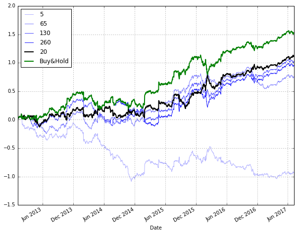

```python
# definition of transparency
alphas = np.array([0.3, 0.5, 0.7, 0.9])
# initialize variable for color storage
rgba_colors = np.zeros((4,4))
# set color to blue
rgba_colors[:,2] = 1
# set the transparency
rgba_colors[:,3] = alphas
# plot all strategies except buy and hold and 20 days
pnl_test[['5','65', '130', '260']].cumsum().plot(color = rgba_colors, figsize=(10,8))
# plot 20 days lookback cumulative pnl
plt.plot(pnl_test[['20']].cumsum(), color = 'black', linewidth = 2, label='20')
# plot the buy and hold cumulative pnl
plt.plot(pnl_test[['Ret']].cumsum(), color = 'green', linewidth = 2, label='Buy&Hold')
# create a guiding grid
plt.grid()
# add labels to legend
plt.legend(loc='best')
```

# 5) Building and testing pair traiding strategies